# | 米饭四溅

米饭四溅

Get busy living, or get busy dying.

[figure not shown]

Mr.Rice

# Toy example for fun research

2023-07-04

#### Highlights:

1. This file was created by Sijian at the date of `2023-06-21`, and last updated at `2023-07-04`.
2. In order to avoid unnecessary errors, please try to install `recommenderlab` package before going forward. You may also like to install other packages if you still encounter problems.

#### 1. Introduction:

- This file is written to show the structure of datasets with side information from DRIMC (`Zhang et al. Bioinformatics, 2020`) and MovieLense (`https://grouplens.org/datasets/movielens/`).
- The current usage of side information was very simple and you should expect it will be updated in the future. Any ideas on pre-processing side information are welcomed!
- Please see below to get a sense of what will be included in the `ToyExample.RData` file.

  ```
  ##  [1] "Cdataset"                       "Cdataset_fused_similarity"
  ##  [3] "Cdataset_similarity"            "LRSSL"
  ##  [5] "LRSSL_fused_similarity"         "LRSSL_similarity"
  ##  [7] "MovieLense"                     "MovieLense100"
  ##  [9] "MovieLense100_binary"           "MovieLense100_fused_similarity"
  ## [11] "MovieLense100_similarity"       "MovieLense50"
  ## [13] "MovieLense50_binary"            "MovieLense50_fused_similarity"
  ## [15] "MovieLense50_similarity"        "MovieLenseMeta"
  ## [17] "MovieLenseMeta100"              "MovieLenseMeta50"
  ## [19] "MovieLenseUser"                 "MovieLenseUser100"
  ## [21] "MovieLenseUser50"               "PREDICT"
  ## [23] "PREDICT_fused_similarity"       "PREDICT_similarity"
  ```

#### 2. About `MovieLense` data

I organized the datasets in the following way:

```
MovieLense
|-- MovieLense50
    |-- Raw data
        |-- rating in 1~5 (MovieLense50)
        |-- rating in binary (MovieLense50_binary)
        |-- users information (MovieLenseUser50)
        |-- movies information (MovieLenseMeta50)
    |-- Processed data
        |-- similarity matrix (MovieLense50_similarity)
            |-- user similarity ($similarity_user)
            |-- user similarity by GIP kernel ($similarity_user_Kgip)
            |-- movie similarity 1 for title ($similarity_movie1)
            |-- movie similarity 2 for year ($similarity_movie2)
            |-- movie similarity 3 for genres ($similarity_movie3)
            |-- movie similarity by GIP kernel ($similarity_movie_Kgip)
        |-- fused similarity matrix (MovieLense50_fused_similarity)
            |-- user fused similarity ($fused_similarity_user)
            |-- user fused similarity with neighborhood ($fused_similarity_user_neighbor)
            |-- movie fused similarity ($fused_similarity_movie)
            |-- movie fused similarity with neighborhood ($fused_similarity_movie_neighbor)
|-- MovieLense100
    ... (similar as above)
```

##### 2.1 The sparse case: *MovieLense50*

**Description:**

- **MovieLense50**: it is a rating matrix in scale 1 to 5. It keeps the records if the users has rated at most 50 movies, AND the moives has been rated at most 50 times.
- **MovieLense50_binary**: it is all the same as above but in a binary case, i.e., yes or no for recommendation, the threshold is rating at 4. You can modify this at different thresholds if you’d like to.
- **MovieLenseUser50**: it has the raw side information for users.
- **MovieLenseMeta50**: it has the raw side information for movies.
- **MovieLense50_similarity**: it includes the similarity matrix for both users and movies, and even their GIP kernel generated similarity matrix.
- **MovieLense50_fused_similarity**: it includes the fused similarity matrix for both users and movies, with possible use of neighborhood information if you’d like to, the current neighborhood size is 20, based on tuning performance.

**Notes:**

- If you do not want to use other packages, then please transfer it as a matrix before going forward:

  ```r
  MovieLense50 = as(MovieLense50,"matrix")
  ```

- Below is the code to select the desired user-movie pairs:

  ```r
  library(recommenderlab)
  data("MovieLense")
  MovieLense50 <- MovieLense[rowCounts(MovieLense) <= 50, colCounts(MovieLense) <= 50]
  MovieLenseMeta50 <- MovieLenseMeta[colCounts(MovieLense) <= 50, ]
  MovieLenseUser50 <- MovieLenseUser[rowCounts(MovieLense) <= 50, ]
  ```

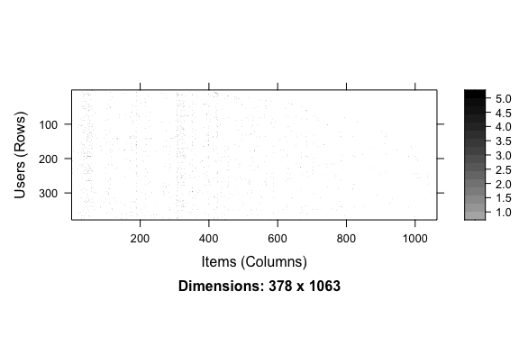

##### 2.2 The dense case: *MovieLense100*

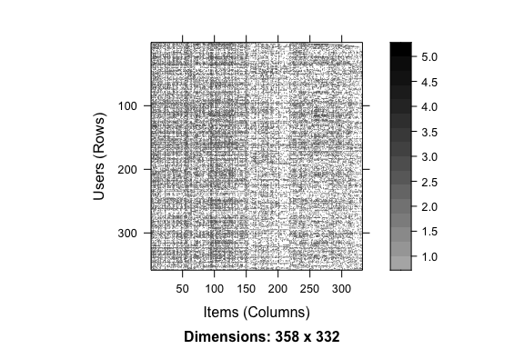

#### 3. About `DRIMC` data

- Here included all three datasets: `Cdataset`, `LRSSL`, and `PREDICT`.
- Because there is no raw side information collected for drugs or diseases, we only provided similarity matrix and fused similarity matrix, but the structure will be very close to the `MovieLense` data. For example, you can check into `Cdataset_similarity`, `Cdataset_fused_similarity` on the first try.
- The neighborhood size was all set as 20, so you can expect (at most) 21 unique values for each drug (or disease) in the similarity matrix if you choose the `$fused_similarity_drug_neighbor` or `$fused_similarity_disease_neighbor`: value of 1 in diagonal, plus 20 different values for 20 neighbors, and all others will be 0.

#### 4. Extra reference

- Below I put the code of pre-processing side information, you can modify it to a more efficient way.

  ```r
  library(stringdist) # used its function stringdist()
  library(vegan) # used its function vegdist()

  # create an empty matrix to store the similarity values
  data_u=MovieLenseUser100[,-1]
  sim_matrix_u <- matrix(0, nrow = nrow(data_u), ncol = nrow(data_u))

  data_v=MovieLenseMeta100[,-3]
  # title: use jw in stringdist
  sim_matrix_v1 <- matrix(0, nrow = nrow(data_v), ncol = nrow(data_v))
  # year: use jaccard in stringdist
  sim_matrix_v2 <- matrix(0, nrow = nrow(data_v), ncol = nrow(data_v))
  # Genres: use vegan for dummy variable, but still Jaccard method
  sim_matrix_v3 <- matrix(0, nrow = nrow(data_v), ncol = nrow(data_v))

  # define a function to calculate the Jaccard similarity between two vectors
  jaccard_sim <- function(x, y) {
    intersect <- length(intersect(x, y))
    union <- length(unique(c(x, y)))
    return(1 - intersect/union)
  }

  # calculate the Jaccard similarity between each pair of rows
  for (i in 1:nrow(data_u)) {
    for (j in 1:nrow(data_u)) {
      if (i != j) {
        sim_matrix_u[i, j] <- 1-jaccard_sim(data_u[i, ], data_u[j, ])
      }
    }
  }
  for (i in 1:nrow(data_v)) {
    for (j in 1:nrow(data_v)) {
      if (i < j) {
        sim_matrix_v1[i, j] <- 1-stringdist(data_v[i, "title"], data_v[j, "title"], method = "jw")
        sim_matrix_v2[i, j] <- 1-jaccard_sim(data_v[i, "year"], data_v[j, "year"])
        sim_matrix_v3[i, j] <- 1-vegdist(rbind(data_v[i, 3:21], data_v[j, 3:21]), method = "jaccard")
      }
    }
  }

  sim_matrix_v1 = sim_matrix_v1+t(sim_matrix_v1)
  sim_matrix_v2 = sim_matrix_v2+t(sim_matrix_v2)
  sim_matrix_v3 = sim_matrix_v3+t(sim_matrix_v3)

  diag(sim_matrix_u)  <- 1
  diag(sim_matrix_v1) <- 1
  diag(sim_matrix_v2) <- 1
  diag(sim_matrix_v3) <- 1
  ```